- **NOTE**: This notebook is trained on Google Colaboratory

# Mask R-CNN

## Cloning & Installing Library

```python
!pip install git+https://github.com/matterport/Mask_RCNN.git
```

```
  Cloning https://github.com/matterport/Mask_RCNN.git to /tmp/pip-req-build-0qjnasr8
  Running command git clone -q https://github.com/matterport/Mask_RCNN.git /tmp/pip-req-build-0qjnasr8
```

## Library Summary

```python
!pip show mask-rcnn
```

```
Name: mask-rcnn
Version: 2.1
Summary: Mask R-CNN for object detection and instance segmentation
Home-page: https://github.com/matterport/Mask_RCNN
Author: Matterport
Author-email: waleed.abdulla@gmail.com
License: MIT
Location: /usr/local/lib/python3.6/dist-packages
Requires:
Required-by:
```

## Getting Pre-trained model

```python
!wget https://github.com/matterport/Mask_RCNN/releases/download/v2.0/mask_rcnn_coco.h5 -O '/tmp/mask_rcnn_coco.h5'
```

```
--2020-05-13 08:44:22--  https://github.com/matterport/Mask_RCNN/releases/download/v2.0/mask_rcnn_coco.h5
Resolving github.com (github.com)... 192.30.255.112
Connecting to github.com (github.com)|192.30.255.112|:443... connected.
HTTP request sent, awaiting response... 302 Found
Location: https://github-production-release-asset-2e65be.s3.amazonaws.com/107595270/872d3234-d21f-11e7-9a51-7b4bc8075835?X-Amz-Algorithm=AWS4-HMAC-SHA256&X-Amz-Credential=AKIAIWNJYAX4CSVEH53A%2F20200513%2Fus-east-1%2Fs3%2Faws4_request&X-Amz-Date=20200513T084423Z&X-Amz-Expires=300&X-Amz-Signature=1cd…
--2020-05-13 08:44:23--  https://github-production-release-asset-2e65be.s3.amazonaws.com/107595270/872d3234-d21f-11e7-9a51-7b4bc8075835?X-Amz-Algorithm=AWS4-HMAC-SHA256&X-Amz-Credential=AKIAIWNJYAX4CSVEH53A%2F20200513%2Fus-east-1%2Fs3%2Faws4_request&X-Amz-Date=20200513T084423Z&X-Amz-Expires=300&X-Am…
Resolving github-production-release-asset-2e65be.s3.amazonaws.com (github-production-release-asset-2e65be.s3.amazonaws.com)... 52.217.64.212
Connecting to github-production-release-asset-2e65be.s3.amazonaws.com (github-production-release-asset-2e65be.s3.amazonaws.com)|52.217.64.212|:443... connected.
HTTP request sent, awaiting response... 200 OK
Length: 257557808 (246M) [application/octet-stream]
Saving to: ‘/tmp/mask_rcnn_coco.h5’

/tmp/mask_rcnn_coco 100%[===================>] 245.63M  47.3MB/s    in 5.7s

2020-05-13 08:44:29 (43.3 MB/s) - ‘/tmp/mask_rcnn_coco.h5’ saved [257557808/257557808]
```

## Importing Libraries

```python
import mrcnn
from mrcnn.config import Config
from mrcnn import visualize
from mrcnn.model import MaskRCNN

import numpy as np
# import tensorflow as tf

from matplotlib.patches import Rectangle
import matplotlib.pyplot as plt
%matplotlib inline
```

```python
!pip install -q tensorflow==1.13.1
import tensorflow as tf
```

## Configuring the model

```python
# define the test configuration
class TestConfig(Config):
    NAME = "test"
    GPU_COUNT = 1
    IMAGES_PER_GPU = 1
    NUM_CLASSES = 1 + 80
```

```python
config = TestConfig()
config.display()
```

```
Configurations:
BACKBONE                       resnet101
BACKBONE_STRIDES               [4, 8, 16, 32, 64]
BATCH_SIZE                     1
BBOX_STD_DEV                   [0.1 0.1 0.2 0.2]
COMPUTE_BACKBONE_SHAPE         None
DETECTION_MAX_INSTANCES        100
DETECTION_MIN_CONFIDENCE       0.7
DETECTION_NMS_THRESHOLD        0.3
FPN_CLASSIF_FC_LAYERS_SIZE     1024
GPU_COUNT                      1
GRADIENT_CLIP_NORM             5.0
IMAGES_PER_GPU                 1
IMAGE_CHANNEL_COUNT            3
IMAGE_MAX_DIM                  1024
IMAGE_META_SIZE                93
IMAGE_MIN_DIM                  800
IMAGE_MIN_SCALE                0
IMAGE_RESIZE_MODE              square
IMAGE_SHAPE                    [1024 1024    3]
LEARNING_MOMENTUM              0.9
LEARNING_RATE                  0.001
LOSS_WEIGHTS                   {'rpn_class_loss': 1.0, 'rpn_bbox_loss': 1.0, 'mrcnn_class_loss': 1.0, 'mrcnn_bbox_loss': 1.0, 'mrcnn_mask_loss': 1.0}
MASK_POOL_SIZE                 14
MASK_SHAPE                     [28, 28]
MAX_GT_INSTANCES               100
MEAN_PIXEL                     [123.7 116.8 103.9]
MINI_MASK_SHAPE                (56, 56)
NAME                           test
NUM_CLASSES                    81
POOL_SIZE                      7
POST_NMS_ROIS_INFERENCE        1000
POST_NMS_ROIS_TRAINING         2000
PRE_NMS_LIMIT                  6000
ROI_POSITIVE_RATIO             0.33
RPN_ANCHOR_RATIOS              [0.5, 1, 2]
RPN_ANCHOR_SCALES              (32, 64, 128, 256, 512)
RPN_ANCHOR_STRIDE              1
RPN_BBOX_STD_DEV               [0.1 0.1 0.2 0.2]
RPN_NMS_THRESHOLD              0.7
RPN_TRAIN_ANCHORS_PER_IMAGE    256
STEPS_PER_EPOCH                1000
TOP_DOWN_PYRAMID_SIZE          256
TRAIN_BN                       False
TRAIN_ROIS_PER_IMAGE           200
USE_MINI_MASK                  True
USE_RPN_ROIS                   True
VALIDATION_STEPS               50
WEIGHT_DECAY                   0.0001
```

## Initializing the model

- We will define the model as type “inference” indicating that we are interested in making predictions and not training.
- We also specify a directory where any log messages could be written, which in this case is the tmp directory.

```python
# define the model
rcnn_model = MaskRCNN(mode='inference', model_dir='./tmp/', config=TestConfig())
```

## Loading Pre-trained model

```python
# load coco model weights
rcnn_model.load_weights('/tmp/mask_rcnn_coco.h5', by_name=True)
```

## Review Weight Stats

```python
# Show stats of all trainable weights
visualize.display_weight_stats(rcnn_model)
```

| WEIGHT NAME | SHAPE | MIN | MAX | STD |
| --- | --- | --- | --- | --- |
| conv1_1/kernel:0 | (7, 7, 3, 64) | -0.8616 | +0.8451 | +0.1315 |
| conv1_1/bias:0 | (64,) | -0.0002 | +0.0004 | +0.0001 |
| bn_conv1_1/gamma:0 | (64,) | +0.0835 | +2.6411 | +0.5091 |
| bn_conv1_1/beta:0 | (64,) | -2.3931 | +5.3610 | +1.9781 |
| bn_conv1_1/moving_mean:0 | (64,) | -173.0470 | +116.3013 | +44.5654 |
| bn_conv1_1/moving_variance:0*** Overflow? | (64,) | +0.0000 | +146335.3594 | +21847.9668 |
| res2a_branch2a_1/kernel:0 | (1, 1, 64, 64) | -0.6574 | +0.3179 | +0.0764 |
| res2a_branch2a_1/bias:0 | (64,) | -0.0022 | +0.0082 | +0.0018 |
| bn2a_branch2a_1/gamma:0 | (64,) | +0.2169 | +1.8489 | +0.4116 |
| bn2a_branch2a_1/beta:0 | (64,) | -2.1180 | +3.7332 | +1.1786 |
| bn2a_branch2a_1/moving_mean:0 | (64,) | -6.1235 | +7.2220 | +2.2789 |
| bn2a_branch2a_1/moving_variance:0 | (64,) | +0.0000 | +8.9258 | +2.0314 |
| res2a_branch2b_1/kernel:0 | (3, 3, 64, 64) | -0.3878 | +0.5070 | +0.0323 |
| res2a_branch2b_1/bias:0 | (64,) | -0.0037 | +0.0026 | +0.0010 |
| bn2a_branch2b_1/gamma:0 | (64,) | +0.3165 | +1.7010 | +0.3042 |
| bn2a_branch2b_1/beta:0 | (64,) | -1.9348 | +4.5429 | +1.5113 |
| bn2a_branch2b_1/moving_mean:0 | (64,) | -6.7752 | +4.5769 | +2.2594 |
| bn2a_branch2b_1/moving_variance:0 | (64,) | +0.0000 | +5.5085 | +1.0835 |
| res2a_branch2c_1/kernel:0 | (1, 1, 64, 256) | -0.4468 | +0.3615 | +0.0410 |
| res2a_branch2c_1/bias:0 | (256,) | -0.0041 | +0.0052 | +0.0016 |
| res2a_branch1_1/kernel:0 | (1, 1, 64, 256) | -0.8674 | +0.7588 | +0.0703 |
| res2a_branch1_1/bias:0 | (256,) | -0.0034 | +0.0025 | +0.0009 |
| bn2a_branch2c_1/gamma:0 | (256,) | -0.5782 | +3.1806 | +0.6192 |
| bn2a_branch2c_1/beta:0 | (256,) | -1.1422 | +1.4273 | +0.4229 |
| bn2a_branch2c_1/moving_mean:0 | (256,) | -4.2602 | +3.0864 | +1.0168 |
| bn2a_branch2c_1/moving_variance:0 | (256,) | +0.0000 | +2.6688 | +0.3827 |
| bn2a_branch1_1/gamma:0 | (256,) | +0.2411 | +3.4973 | +0.6241 |
| bn2a_branch1_1/beta:0 | (256,) | -1.1422 | +1.4274 | +0.4229 |
| bn2a_branch1_1/moving_mean:0 | (256,) | -8.0883 | +8.6554 | +2.0289 |
| bn2a_branch1_1/moving_variance:0 | (256,) | +0.0000 | +8.7306 | +1.5526 |

[output cut: 660 more lines]

## Loading Image

```python
img_path = '/content/drive/My Drive/Colab Notebooks/volvo_cars_employees_2019_sub_hero.webp'
img = tf.keras.preprocessing.image.load_img(img_path)
img = tf.keras.preprocessing.image.img_to_array(img)
```

## Running the model

```python
# make prediction
results = rcnn_model.detect([img])
```

- The result contains a dictionary for each image that we passed into the detect() function, in this case, a list of a single dictionary for the one image.
- The keys of the dictionary of note are as follows:
  - **rois**: The bound boxes or regions-of-interest (ROI) for detected objects.
  - **masks**: The masks for the detected objects.
  - **class_ids**: The class integers for the detected objects.
  - **scores**: The probability or confidence for each predicted class.

```python
results[0].keys()
```

```
dict_keys(['rois', 'class_ids', 'scores', 'masks'])
```

## Visualizing results

[figure not shown]

```python
# draw an image with detected objects
def draw_image_with_boxes(filepath, boxes_list):
    # load the image
    data = plt.imread(filepath)

    # plot the image
    plt.figure(figsize=(20, 12))
    plt.xticks(ticks=[])
    plt.yticks(ticks=[])
    plt.imshow(data)

    # get the context for drawing boxes
    ax = plt.gca()

    # plot each box
    for box in boxes_list:
        # get coordinates
        y1, x1, y2, x2 = box

        # calculate width and height of the box
        width, height = x2 - x1, y2 - y1

        # create the shape
        rect = Rectangle((x1, y1), width, height, fill=False, color='red')

        # draw the box
        ax.add_patch(rect)

# visualize the results
draw_image_with_boxes(img_path, results[0]['rois'])
```

- The Mask_RCNN API provides a function called display_instances() that will take the array of pixel values for the loaded image and the aspects of the prediction dictionary, such as the bounding boxes, scores, and class labels, and will plot the photo with all of these annotations.
- One of the arguments is the list of predicted class identifiers available in the ‘class_ids‘ key of the dictionary. The function also needs a mapping of ids to class labels. The pre-trained model was fit with a dataset that had 80 (81 including background) class labels.

```python
# COCO Class names
# Index of the class in the list is its ID. For example, to get ID of
# the teddy bear class, use: class_names.index('teddy bear')

class_names = ['BG', 'person', 'bicycle', 'car', 'motorcycle', 'airplane',
               'bus', 'train', 'truck', 'boat', 'traffic light',
               'fire hydrant', 'stop sign', 'parking meter', 'bench', 'bird',
               'cat', 'dog', 'horse', 'sheep', 'cow', 'elephant', 'bear',
               'zebra', 'giraffe', 'backpack', 'umbrella', 'handbag', 'tie',
               'suitcase', 'frisbee', 'skis', 'snowboard', 'sports ball',
               'kite', 'baseball bat', 'baseball glove', 'skateboard',
               'surfboard', 'tennis racket', 'bottle', 'wine glass', 'cup',
               'fork', 'knife', 'spoon', 'bowl', 'banana', 'apple',
               'sandwich', 'orange', 'broccoli', 'carrot', 'hot dog', 'pizza',
               'donut', 'cake', 'chair', 'couch', 'potted plant', 'bed',
               'dining table', 'toilet', 'tv', 'laptop', 'mouse', 'remote',
               'keyboard', 'cell phone', 'microwave', 'oven', 'toaster',
               'sink', 'refrigerator', 'book', 'clock', 'vase', 'scissors',
               'teddy bear', 'hair drier', 'toothbrush']

print(len(class_names))
```

```
81
```

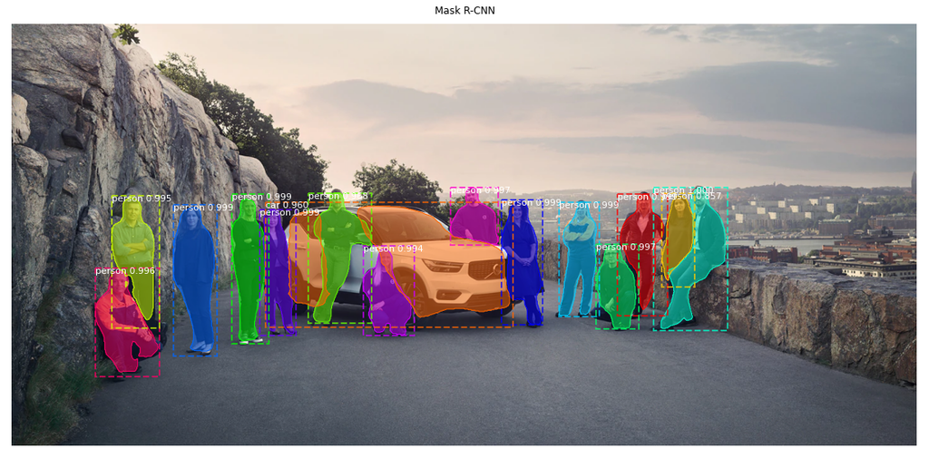

```python
visualize.display_instances(
    image=img,
    boxes=results[0]['rois'],
    masks=results[0]['masks'],
    class_ids=results[0]['class_ids'],
    class_names=class_names,
    scores=results[0]['scores'],
    title='Mask R-CNN',
    figsize=(20, 12),
    show_mask=True,
    show_bbox=True
)
```

- Output consist of-
  - **Bounding Box**: Dotted bounding box around each detected object.
  - **Class Label**: Class label assigned each detected object written in the top left corner of the bounding box.
  - **Prediction Confidence**: Confidence of class label prediction for each detected object written in the top left corner of the bounding box.
  - **Object Mask Outline**: Polygon outline for the mask of each detected object.
  - **Object Mask**: Polygon fill for the mask of each detected object.

## Analyzing masks

```python
mask = results[0]['masks']
mask = mask.astype('int')
mask.shape
```

```
(670, 1440, 15)
```

- These masks are in the boolean form (True and False) and hence we convert them to numbers (1 and 0).
- This will give us an array of 0s and 1s, where 0 means that there is no object at that particular pixel and 1 means that there is an object at that pixel.
- Note that the shape of the mask is similar to that of the original image.
- However, the 15 here in the shape of the mask does not represent the channels. Instead, it represents the number of objects segmented by our model.

[output not shown]

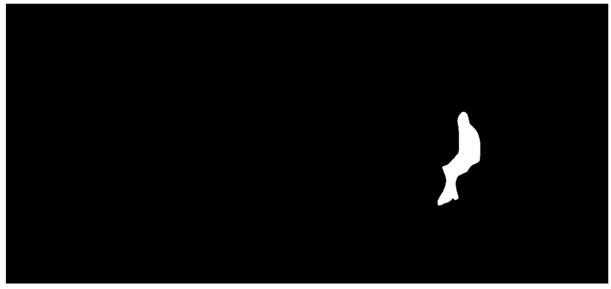

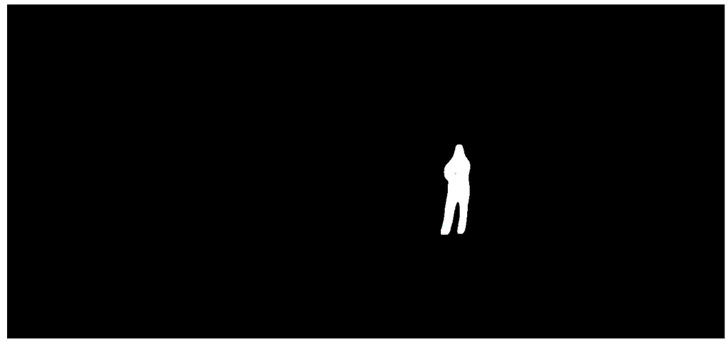

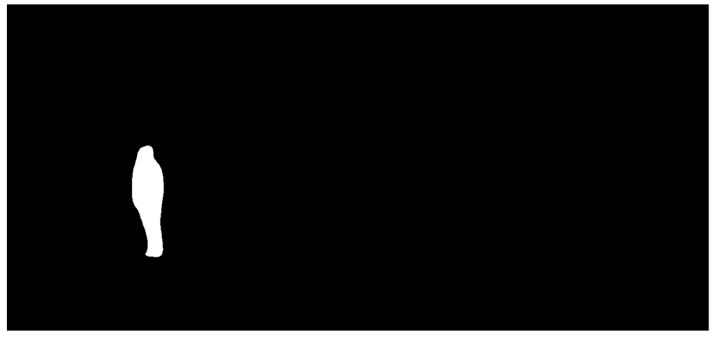

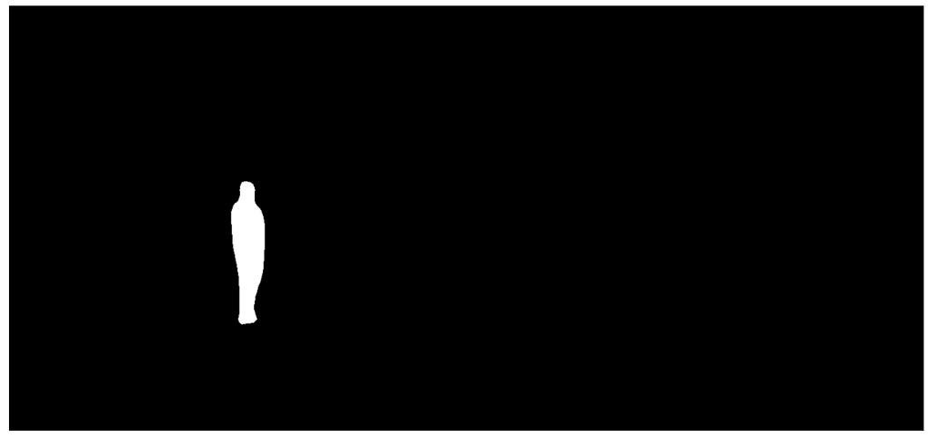

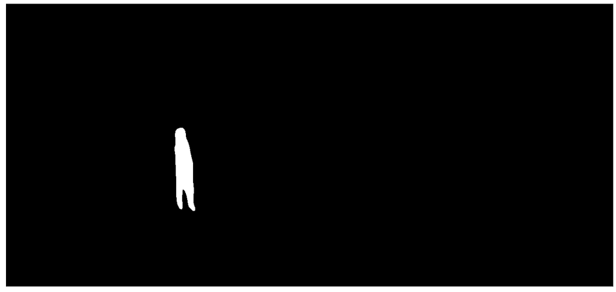

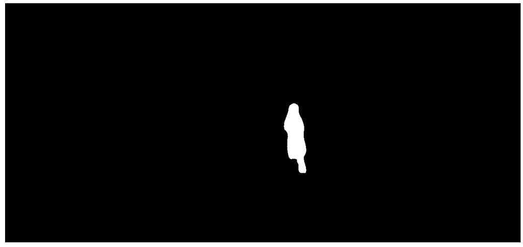

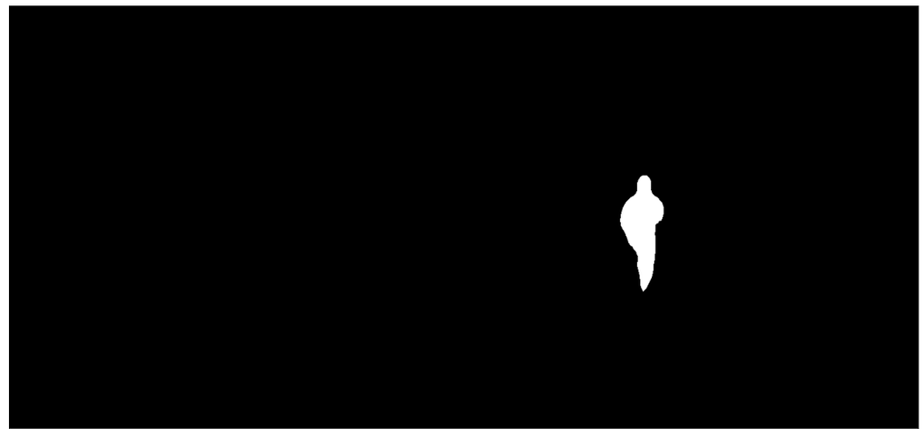

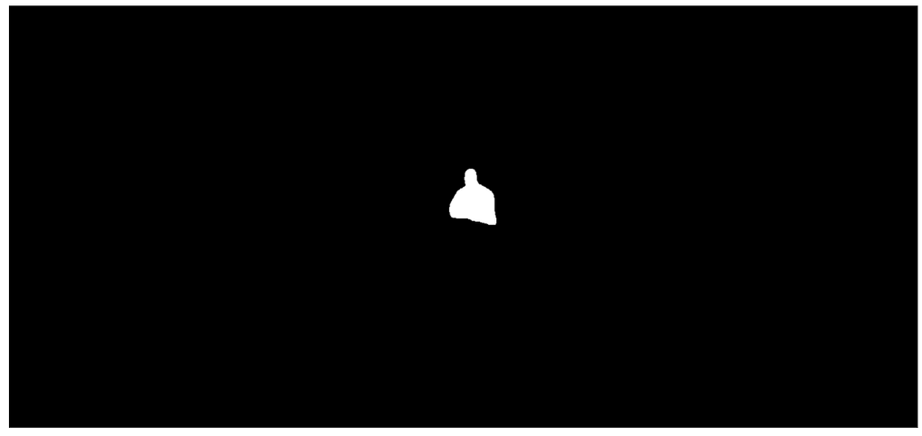

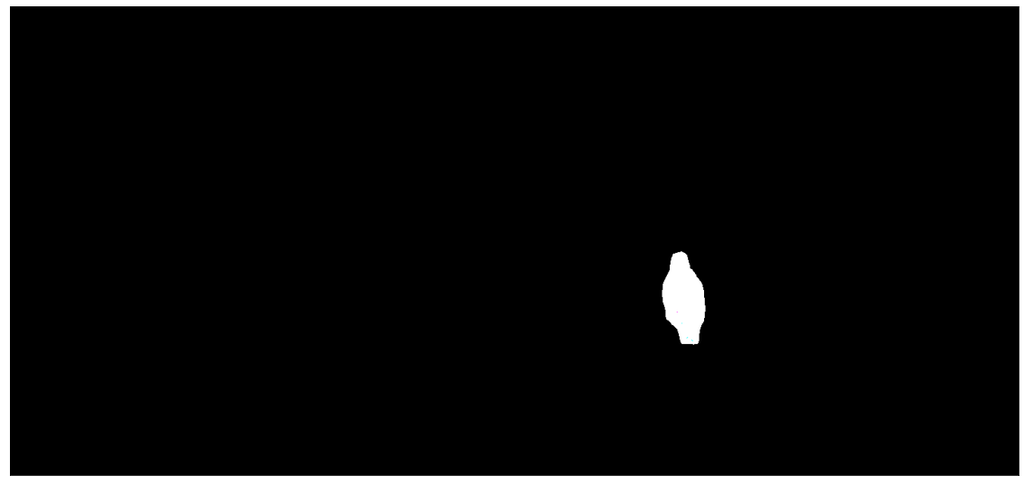

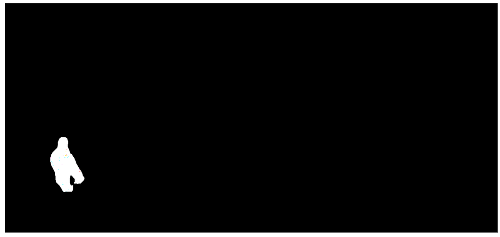

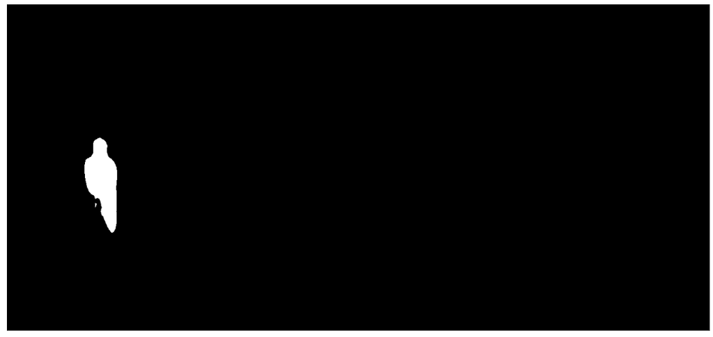

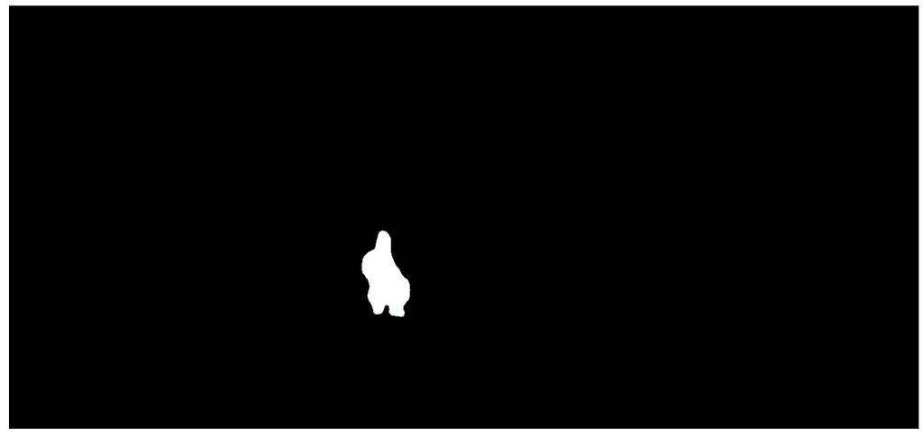

[3 more figures not shown]

```python
# To output each individual objects
for i in range(mask.shape[2]):
    temp = tf.keras.preprocessing.image.load_img(img_path)
    temp = tf.keras.preprocessing.image.img_to_array(temp)
    for j in range(temp.shape[2]):
        temp[:,:,j] = temp[:,:,j] * mask[:,:,i]

    plt.figure(figsize=(20, 12))
    plt.xticks(ticks=[])
    plt.yticks(ticks=[])

    # The reason is that if the color intensity is a float, then matplotlib expects it to range from 0 to 1. If an int, then it expects 0 to 255.
    # plt.imshow(temp.astype('uint8'))
    plt.imshow(temp.astype('float32'))
```